# Intro Datenanalyse mit R

# Regressionsdiagnostik mit R-Paket `visreg`

# Regressionsdiagnostik mit Basis-R

Ein einfaches Modell

```r
N <- 5
x1 <- rnorm(N)
y <- runif(N)
```

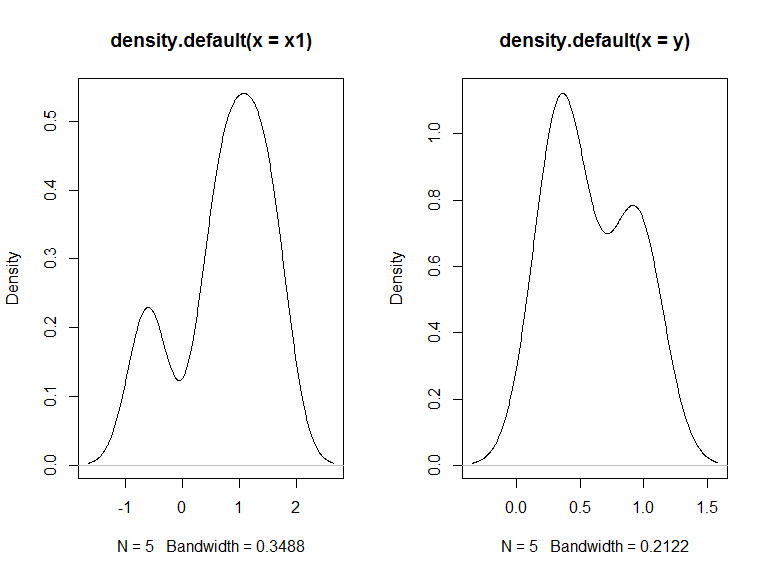

```r
par(mfrow=c(1,2))
plot(density(x1))
plot(density(y))
```

# Modellvorhersage machen

```r
mod1 <- lm(y~x1)
pre <- predict(mod1)
y
```

```
## [1] 0.9411023 0.3828133 0.3874452 0.9460138 0.2913519
```

```r
pre
```

```
##         1         2         3         4         5
## 0.5951064 0.6200788 0.6078568 0.5829215 0.5427631
```

# Regressionsdiagnostik mit Basis-R

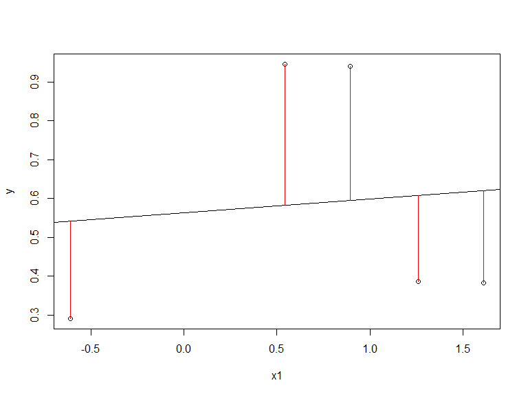

```r
plot(x1,y)
abline(mod1)
segments(x1, y, x1, pre, col="red")
```

# Beispieldaten Luftqualität

```r
library(datasets)
?airquality
```

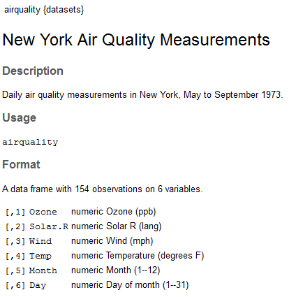

# Das `visreg`-Paket

Ein Modell wird auf dem airquality Datensatz geschätzt

```r
install.packages("visreg")
```

```r
library(visreg)
fit <- lm(Ozone ~ Solar.R + Wind + Temp, data = airquality)
summary(fit)
```

```
##
## Call:
## lm(formula = Ozone ~ Solar.R + Wind + Temp, data = airquality)
##
## Residuals:
##     Min      1Q  Median      3Q     Max
## -40.485 -14.219  -3.551  10.097  95.619
##
## Coefficients:
##              Estimate Std. Error t value Pr(>|t|)
## (Intercept) -64.34208   23.05472  -2.791  0.00623 **
## Solar.R       0.05982    0.02319   2.580  0.01124 *
## Wind         -3.33359    0.65441  -5.094 1.52e-06 ***
## Temp          1.65209    0.25353   6.516 2.42e-09 ***
## ---
## Signif. codes:  0 '***' 0.001 '**' 0.01 '*' 0.05 '.' 0.1 ' ' 1
##
## Residual standard error: 21.18 on 107 degrees of freedom
##   (42 observations deleted due to missingness)
## Multiple R-squared:  0.6059, Adjusted R-squared:  0.5948
## F-statistic: 54.83 on 3 and 107 DF,  p-value: < 2.2e-16
```

# Visualisierung

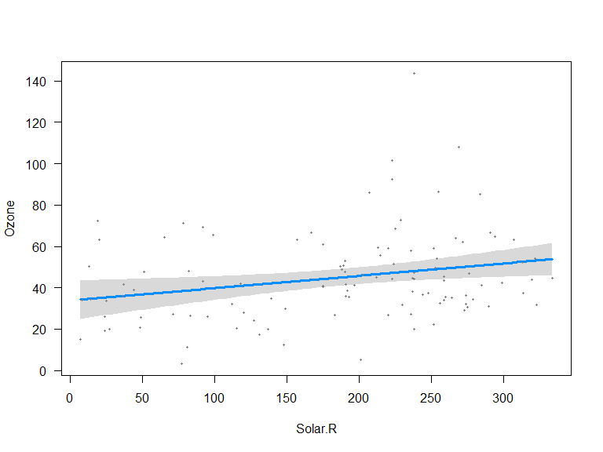

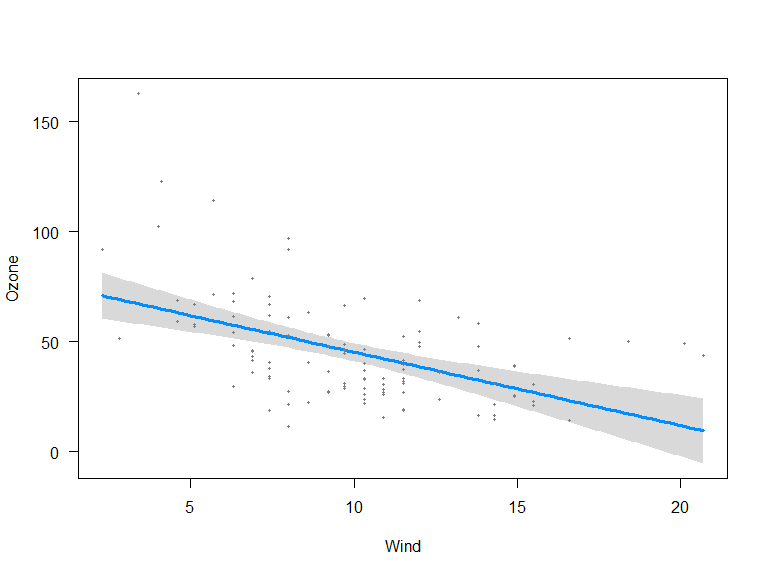

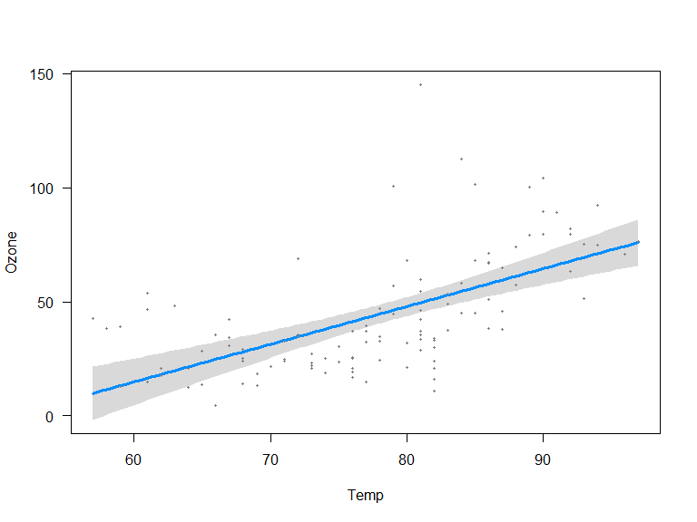

```r
visreg(fit)
```

# [Und dann mit `visreg` visualisiert.](http://myweb.uiowa.edu/pbreheny/publications/visreg.pdf)

- Zweites Argument - Spezifikation erklärende Variable für Visualisierung

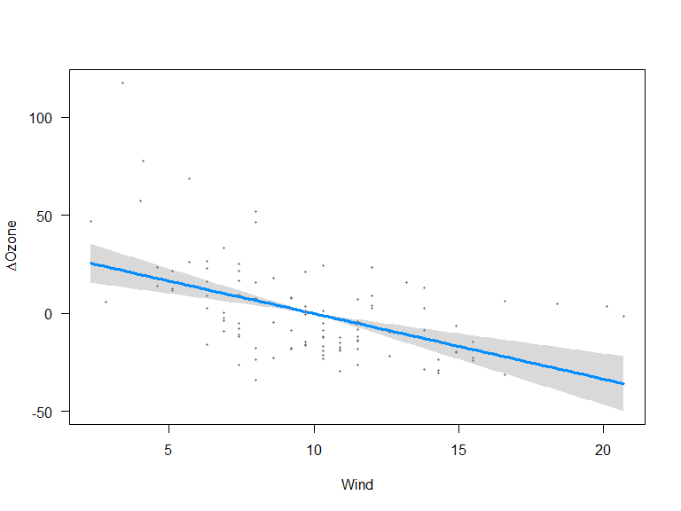

```r
visreg(fit, "Wind", type = "contrast")
```

# Visualisierung mit dem Paket `visreg`

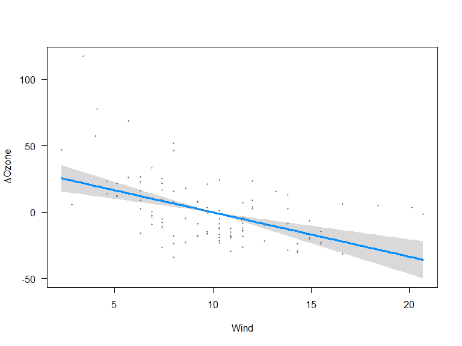

```r
visreg(fit, "Wind", type = "contrast")
```

# Das `visreg`-Paket

- Das Default-Argument für type ist conditional.

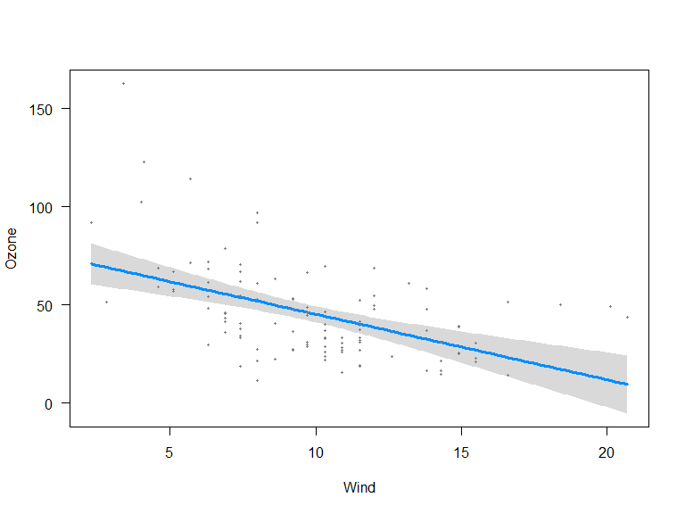

```r
visreg(fit, "Wind", type = "conditional")
```

# Regression mit Faktoren

Mit `visreg` können die Effekte bei Faktoren visualisiert werden.

```r
airquality$Heat <- cut(airquality$Temp, 3,
    labels=c("Cool", "Mild", "Hot"))
fit.heat <- lm(Ozone ~ Solar.R + Wind + Heat,
    data = airquality)
summary(fit.heat)
```

```
##
## Call:
## lm(formula = Ozone ~ Solar.R + Wind + Heat, data = airquality)
##
## Residuals:
##     Min      1Q  Median      3Q     Max
## -33.473 -12.794  -2.686   8.461 107.035
##
## Coefficients:
##             Estimate Std. Error t value Pr(>|t|)
## (Intercept) 48.27682    8.83072   5.467 3.07e-07 ***
## Solar.R      0.06524    0.02145   3.042  0.00296 **
## Wind        -3.49803    0.59042  -5.925 3.94e-08 ***
## HeatMild     9.05367    4.88257   1.854  0.06648 .
## HeatHot     43.13970    5.98618   7.207 8.79e-11 ***
## ---
## Signif. codes:  0 '***' 0.001 '**' 0.01 '*' 0.05 '.' 0.1 ' ' 1
##
## Residual standard error: 19.9 on 106 degrees of freedom
##   (42 observations deleted due to missingness)
## Multiple R-squared:  0.6554, Adjusted R-squared:  0.6424
## F-statistic:  50.4 on 4 and 106 DF,  p-value: < 2.2e-16
```

# Effekte von Faktoren

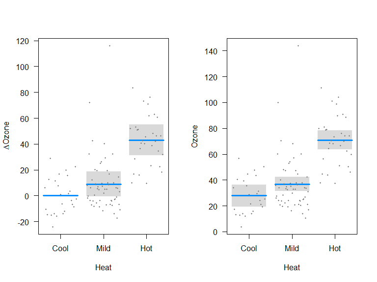

```r
par(mfrow=c(1,2))
visreg(fit.heat, "Heat", type = "contrast")
visreg(fit.heat, "Heat", type = "conditional")
```

# Das Paket visreg - Interaktionen

```r
airquality$Heat <- cut(airquality$Temp, 3,
labels=c("Cool", "Mild", "Hot"))
fit <- lm(Ozone ~ Solar.R + Wind * Heat, data = airquality)
summary(fit)
```

```
##
## Call:
## lm(formula = Ozone ~ Solar.R + Wind * Heat, data = airquality)
##
## Residuals:
##     Min      1Q  Median      3Q     Max
## -34.472 -11.640  -1.919   7.403 102.428
##
## Coefficients:
##               Estimate Std. Error t value Pr(>|t|)
## (Intercept)    4.48042   17.38219   0.258 0.797102
## Solar.R        0.07634    0.02137   3.572 0.000538 ***
## Wind           0.05854    1.34860   0.043 0.965458
## HeatMild      56.72928   18.53110   3.061 0.002805 **
## HeatHot       94.68619   18.61619   5.086 1.63e-06 ***
## Wind:HeatMild -4.11933    1.57108  -2.622 0.010054 *
## Wind:HeatHot  -4.88125    1.74358  -2.800 0.006101 **
## ---
## Signif. codes:  0 '***' 0.001 '**' 0.01 '*' 0.05 '.' 0.1 ' ' 1
##
## Residual standard error: 19.28 on 104 degrees of freedom
##   (42 observations deleted due to missingness)
## Multiple R-squared:  0.6825, Adjusted R-squared:  0.6642
## F-statistic: 37.26 on 6 and 104 DF,  p-value: < 2.2e-16
```

# Steuern der Graphikausgabe mittels `layout`

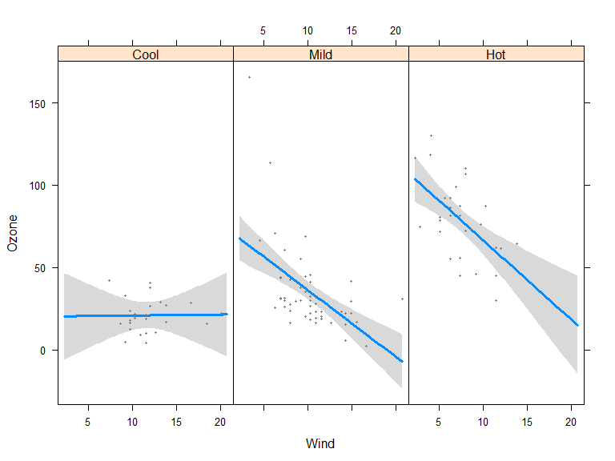

```r
visreg(fit, "Wind", by = "Heat",layout=c(3,1))
```

# Das Paket `visreg` - Interaktionen overlay

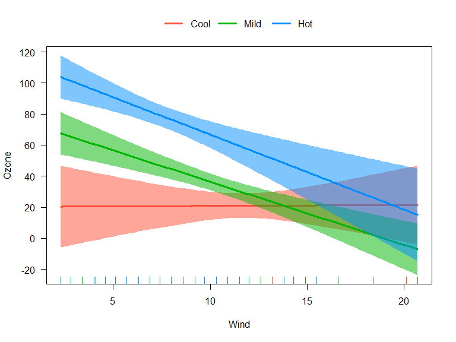

```r
fit <- lm(Ozone ~ Solar.R + Wind * Heat, data = airquality)
visreg(fit, "Wind", by="Heat", overlay=TRUE, partial=FALSE)
```

# Das Paket `visreg` - `visreg2d`

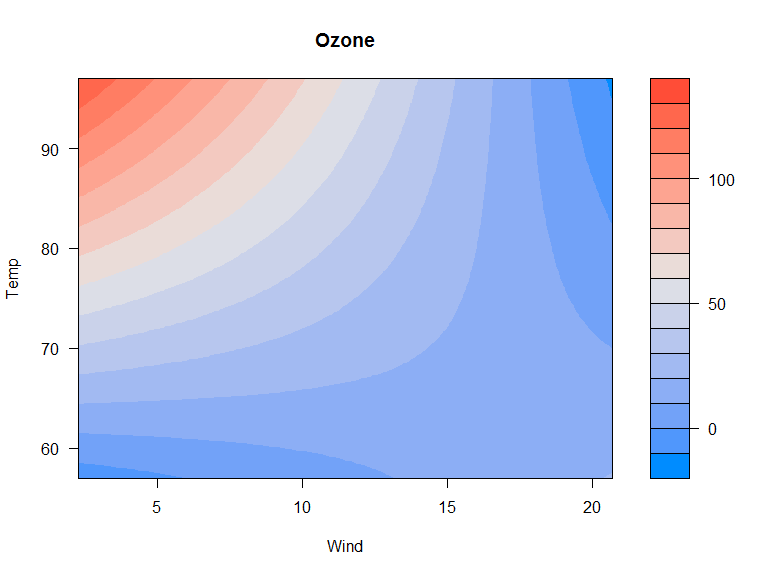

```r
fit2 <- lm(Ozone ~ Solar.R + Wind * Temp, data = airquality)
visreg2d(fit2, "Wind", "Temp", plot.type = "image")
```

# Das Paket visreg - surface

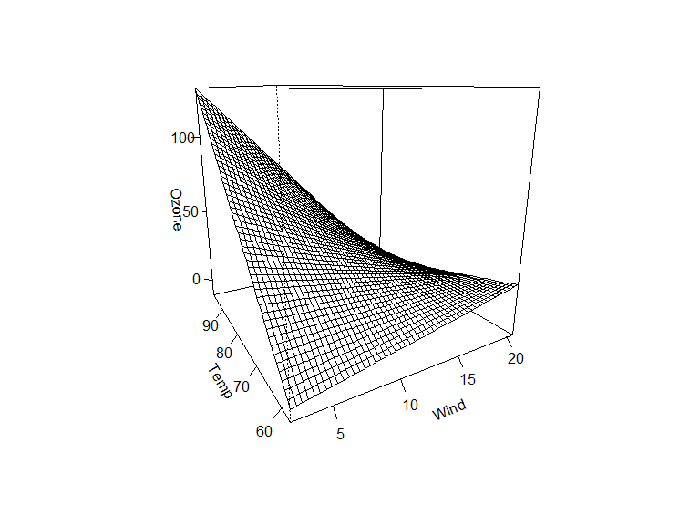

```r
visreg2d(fit2, "Wind", "Temp", plot.type = "persp")
```

# Karten erstellen mit maptools

# Das Paket maptools

- Datensatz `wrld_simpl` aus dem Paket [maptools](https://cran.r-project.org/web/packages/maptools/index.html)
- Polygone für fast alle Staaten der Erde

```r
library(maptools)
data(wrld_simpl)
```

[output not shown]

# Hello world

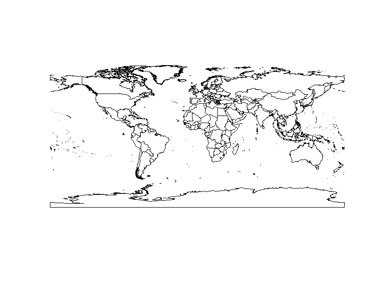

```r
data(wrld_simpl)
plot(wrld_simpl)
```

# Der shapefile

- Es handelt sich um einen `shapefile`

```r
typeof(wrld_simpl)
```

```
## [1] "S4"
```

- Die Daten sind als `S4` abgespeichert
- Es gibt verschiedene Slots
- In einem davon ist Information als `data.frame` gespeichert.

# Der Datensatz

```r
head(wrld_simpl@data)
```

|  | FIPS | ISO2 | ISO3 | UN | NAME |
| --- | --- | --- | --- | --- | --- |
| ATG | AC | AG | ATG | 28 | Antigua and Barbuda |
| DZA | AG | DZ | DZA | 12 | Algeria |
| AZE | AJ | AZ | AZE | 31 | Azerbaijan |
| ALB | AL | AL | ALB | 8 | Albania |

# Die Struktur der Daten

```r
head(wrld_simpl@data$NAME)
```

```
## [1] Antigua and Barbuda Algeria             Azerbaijan
## [4] Albania             Armenia             Angola
## 246 Levels: Aaland Islands Afghanistan Albania Algeria ... Zimbabwe
```

```r
head(wrld_simpl@data$ISO2)
```

```
## [1] AG DZ AZ AL AM AO
## 246 Levels: AD AE AF AG AI AL AM AN AO AQ AR AS AT AU AW AX AZ BA BB ... ZW
```

```r
head(wrld_simpl@data$POP2005)
```

```
## [1]    83039 32854159  8352021  3153731  3017661 16095214
```

# Eine logische Abfrage

```r
ind_SA <- wrld_simpl@data$NAME =="South Africa"
head(ind_SA)
```

```
## [1] FALSE FALSE FALSE FALSE FALSE FALSE
```

```r
table(ind_SA)
```

```
## ind_SA
## FALSE  TRUE
##   245     1
```

# Eine Karte für Süd Afrika

- Ein Land zeichnen

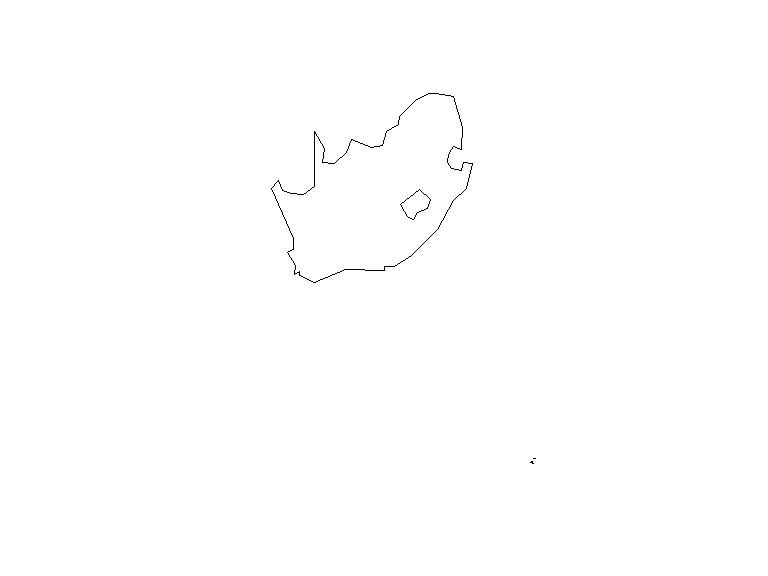

```r
SouthAfrica <- wrld_simpl[ind_SA,]
plot(SouthAfrica)
```

# Mehr als ein Land zeichnen

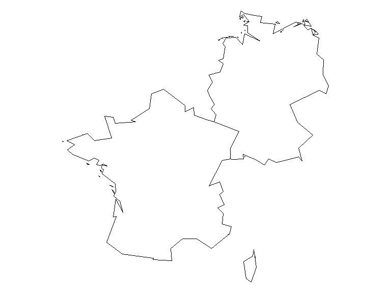

```r
EuropeList <- c('Germany', 'France')
my_map <- wrld_simpl[wrld_simpl$NAME %in% EuropeList, ]
par(mai=c(0,0,0,0))
plot(my_map)
```

# Mehr Farbe

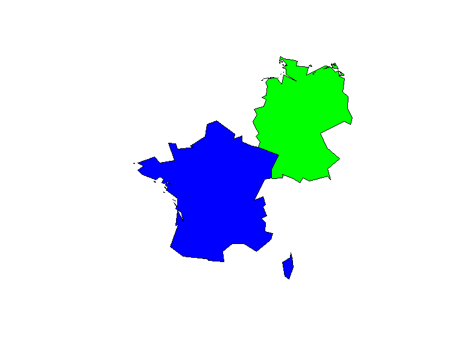

```r
my_map@data$color <- c("blue","green")
plot(my_map,col=my_map@data$color)
```

# Mehr Farbe für die Welt

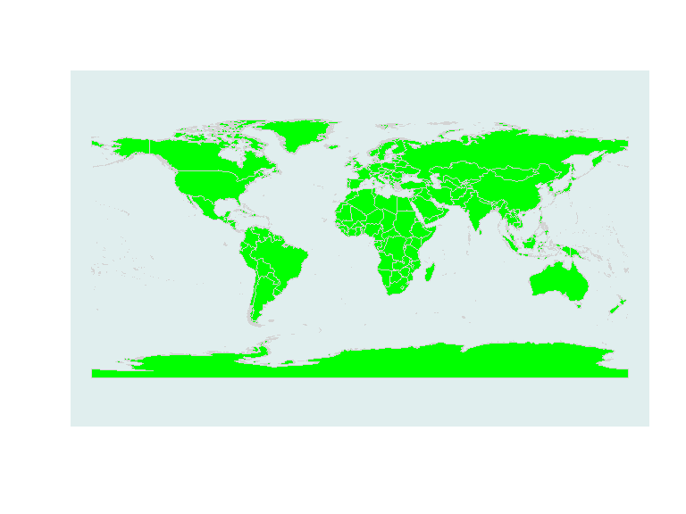

```r
plot(wrld_simpl, bg='azure2', col='green',
     border='lightgray')
```

# Eine Karte für Europa

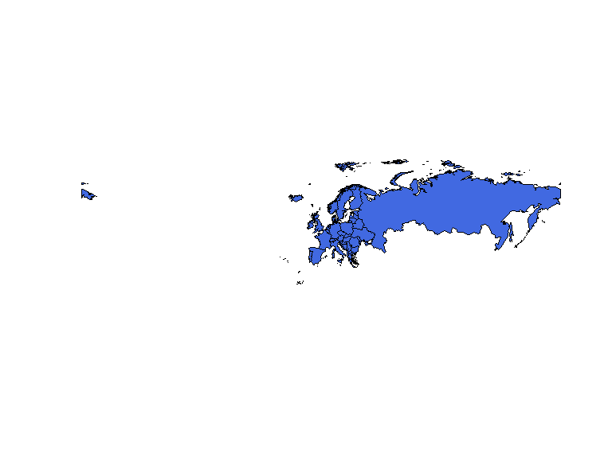

```r
Europe <- wrld_simpl[wrld_simpl$REGION=="150",]
plot(Europe,col="royalblue")
```

# Europa ohne Russland

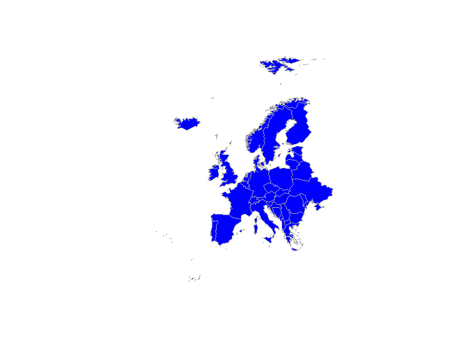

```r
ind <- which(Europe@data$NAME=="Russia")
EU <- Europe[-ind,]
plot(EU,col="blue",border="darkgray")
```

# Spielen Sie mit Farben

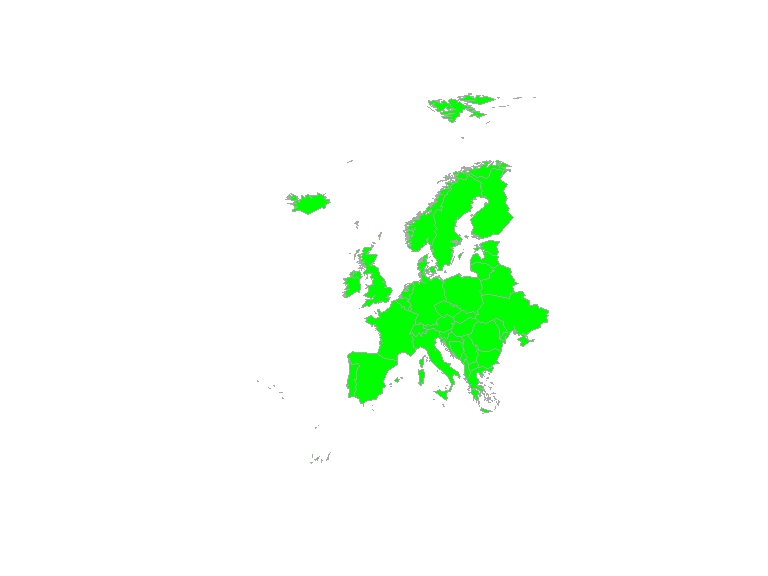

```r
EU$colors <- "green"
plot(EU,col=EU$colors,border="darkgray")
```

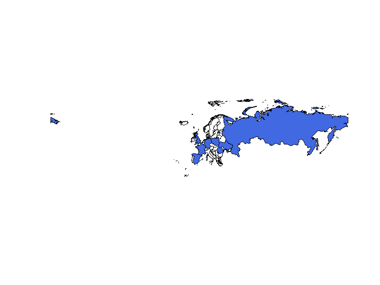

```r
pop05 <- Europe$POP2005
Europe$colors[pop05>mean(pop05)] <- "royalblue"
plot(Europe,col=Europe$colors)
```

# Mehr über Farben

[Colors in R](http://www.stat.columbia.edu/~tzheng/files/Rcolor.pdf)

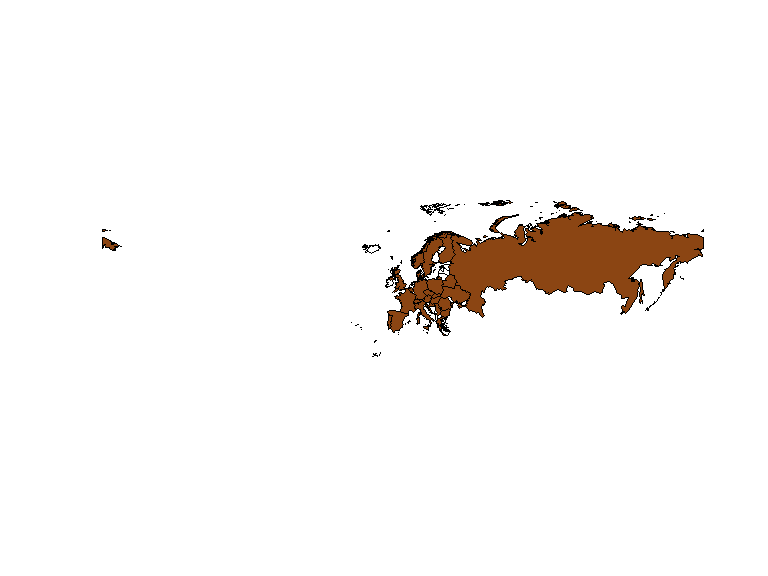

```r
Europe$colors[pop05>median(pop05)] <- "chocolate4"
plot(Europe,col=Europe$colors)
```

# Europa - Farbschattierung blau

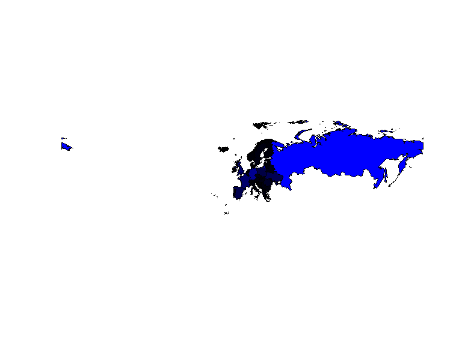

```r
val <- Europe$POP2005/max(Europe$POP2005)
plot(Europe,col=rgb(0,0,val))
```

# Europa - Farbschattierung rot

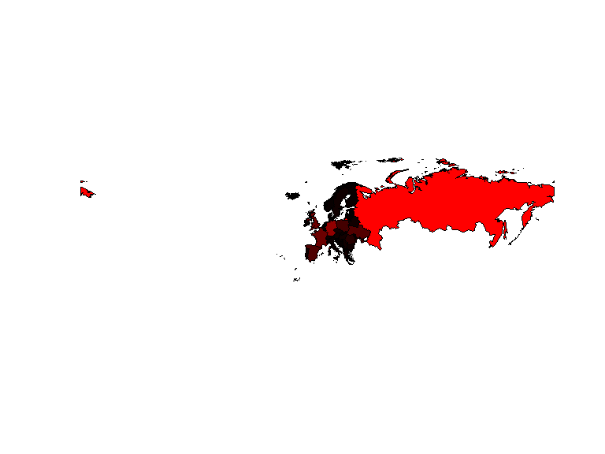

```r
val <- Europe$POP2005/max(Europe$POP2005)
plot(Europe,col=rgb(val,0,0))
```

# Europa - Farbschattierung grün

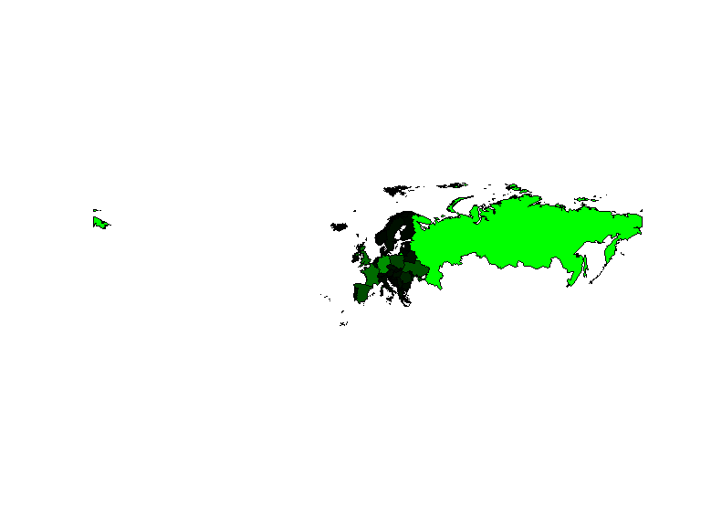

```r
val <- Europe$POP2005/max(Europe$POP2005)
plot(Europe,col=rgb(0,val,0))
```

# Europa - Farbschattierung grau

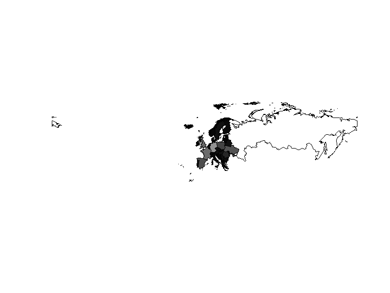

```r
val <- Europe$POP2005/max(Europe$POP2005)
plot(Europe,col=rgb(val,val,val))
```

# Europa - zwei Graphiken nebeneinander

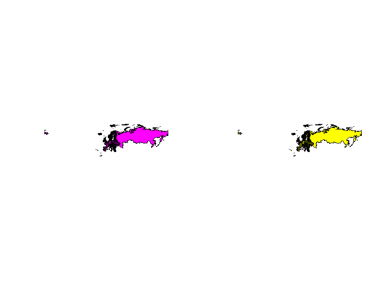

```r
par(mfrow=c(1,2))
plot(Europe,col=rgb(val,0,val))
plot(Europe,col=rgb(val,val,0))
```

# Europa - Punkte hinzufügen

```r
which(Europe$ISO2=="FR") # 10
```

```
## [1] 10
```

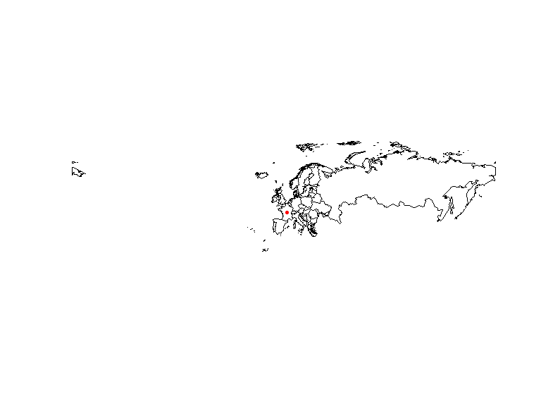

```r
plot(Europe)
points(Europe$LON[10],Europe$LAT[10],col="red",pch=20)
```

# Europa - Blasen hinzufügen

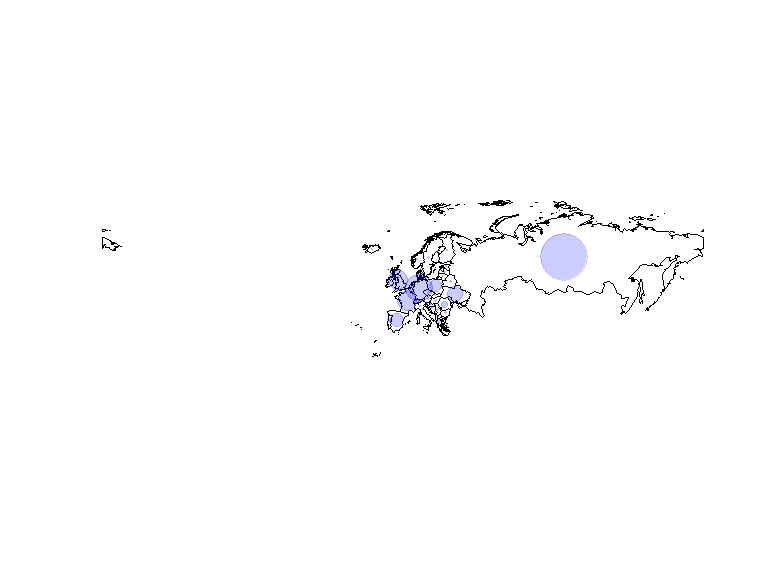

```r
pop <- Europe$POP2005
pop <- pop/max(pop)*10
plot(Europe)
points(Europe$LON,Europe$LAT,cex=pop,col=rgb(0,0,1,.2),
pch=20)
```